# Poisonous or Edible? A Mushroom Classifier

### A classification case study where being wrong has a body count

This notebook is a portfolio case study by **AbleVLabs**. It works end to end with the classic **UCI Mushroom** dataset: 8,124 real mushrooms described by the 1981 Audubon Society field guide, each labeled edible or poisonous, each described by 22 categorical traits like odor, gill size, spore print color, and habitat.

The reason this problem is worth doing is the **cost of a mistake**. If a spam filter is wrong, an email lands in the wrong folder. If this classifier is wrong in one particular direction, someone eats a poisonous mushroom. That asymmetry is the whole lesson: a model can be 99.9 percent accurate and still be unsafe, and only the confusion matrix, not the accuracy score, will tell you so.

## 1. The data

Every column is categorical, encoded as a single letter in the raw file. The target is `class`: `e` for edible, `p` for poisonous. There are no numeric columns, so this is a clean showcase of **one-hot encoding** rather than scaling or outlier work.

```python
import json, numpy as np, pandas as pd
import matplotlib.pyplot as plt, matplotlib.ticker as mtick
from sklearn.model_selection import train_test_split
from sklearn.linear_model import LogisticRegression
from sklearn.tree import DecisionTreeClassifier, export_text
from sklearn.metrics import (accuracy_score, precision_score, recall_score, f1_score,
                             confusion_matrix, roc_curve, roc_auc_score)

plt.rcParams.update({'figure.facecolor':'#0d0d12','axes.facecolor':'#12121a',
  'savefig.facecolor':'#0d0d12','text.color':'#e8e8ef','axes.labelcolor':'#e8e8ef',
  'xtick.color':'#a9a9c0','ytick.color':'#a9a9c0','axes.edgecolor':'#2a2a3a',
  'grid.color':'#20202c','font.size':11,'axes.titlecolor':'#e8e8ef','figure.dpi':110})
CY,PU,GR,AM,RED = '#22d3ee','#a855f7','#34d399','#f59e0b','#ef4444'

df = pd.read_csv('mushrooms.csv')
print('shape:', df.shape)
df.head()
```

```
shape: (8124, 23)
```

|  | class | cap-shape | cap-surface | cap-color | bruises | odor | gill-attachment | gill-spacing | gill-size | gill-color | ... | stalk-surface-below-ring | stalk-color-above-ring | stalk-color-below-ring | veil-type | veil-color | ring-number | ring-type | spore-print-color | population | habitat |
| --- | --- | --- | --- | --- | --- | --- | --- | --- | --- | --- | --- | --- | --- | --- | --- | --- | --- | --- | --- | --- | --- |
| 0 | p | x | s | n | t | p | f | c | n | k | ... | s | w | w | p | w | o | p | k | s | u |
| 1 | e | x | s | y | t | a | f | c | b | k | ... | s | w | w | p | w | o | p | n | n | g |
| 2 | e | b | s | w | t | l | f | c | b | n | ... | s | w | w | p | w | o | p | n | n | m |
| 3 | p | x | y | w | t | p | f | c | n | n | ... | s | w | w | p | w | o | p | k | s | u |
| 4 | e | x | s | g | f | n | f | w | b | k | ... | s | w | w | p | w | o | e | n | a | g |

5 rows × 23 columns

```python
# human-readable decode for the categorical codes (from the UCI data dictionary)
DECODE = json.load(open('mushroom.json'))['decode']
def human(col, code): return DECODE.get(col, {}).get(code, code)

print('class balance:')
print(df['class'].map({'e':'edible','p':'poisonous'}).value_counts())
```

```
class balance:
class
edible       4208
poisonous    3916
Name: count, dtype: int64
```

## 2. Cleaning

Two things need attention before modeling, and both are judgment calls worth showing.

**A constant column.** `veil-type` has the same value for every single mushroom, so it carries zero information and is dropped.

**Missing values.** `stalk-root` has 2,480 entries marked `?`. That is almost a third of the data, so dropping those rows would be wasteful. Instead the `?` is kept as its own category, `missing`. For a tree-based model this is a clean, honest choice: "we do not know the stalk root" can itself be predictive.

```python
const_cols = [c for c in df.columns if c!='class' and df[c].nunique()==1]
stalk_missing = int((df['stalk-root']=='?').sum())
print('constant columns dropped:', const_cols)
print("stalk-root '?' kept as its own 'missing' category:", stalk_missing, 'rows')

df2 = df.drop(columns=const_cols)
feat_cols = [c for c in df2.columns if c!='class']
print('features remaining:', len(feat_cols))
```

```
constant columns dropped: ['veil-type']
stalk-root '?' kept as its own 'missing' category: 2480 rows
features remaining: 21
```

## 3. Exploring the strongest signal: odor

Before any model, one feature tells most of the story. Grouping by **odor** and coloring by class shows an almost perfect separation. Every foul, fishy, spicy, pungent, creosote, or musty mushroom in this data is poisonous. Almond and anise are edible. The only overlap is "no odor," which is mostly edible with a small poisonous minority.

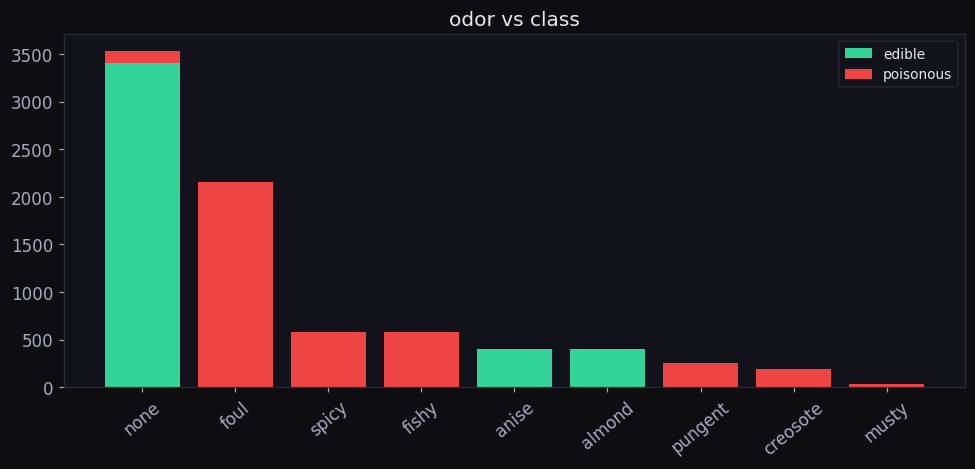

```python
def stacked(col, ax):
    g = df.groupby([col,'class']).size().unstack(fill_value=0)
    labels = [human(col,c) for c in g.index]
    e = g.get('e', pd.Series(0,index=g.index)).values
    p = g.get('p', pd.Series(0,index=g.index)).values
    order = np.argsort(-(e+p))
    labels=[labels[i] for i in order]; e=e[order]; p=p[order]
    ax.bar(labels, e, color=GR, label='edible')
    ax.bar(labels, p, bottom=e, color=RED, label='poisonous')
    ax.set_title(f'{col} vs class'); ax.tick_params(axis='x', rotation=40)
    ax.legend(facecolor='#12121a', edgecolor='#2a2a3a', labelcolor='#e8e8ef', fontsize=9)

fig, ax = plt.subplots(figsize=(9,4.4)); stacked('odor', ax); plt.tight_layout(); plt.show()
```

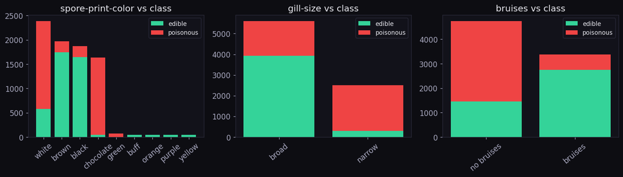

```python
# three more telling features
fig, axes = plt.subplots(1,3, figsize=(13,3.8))
for a,c in zip(axes, ['spore-print-color','gill-size','bruises']): stacked(c,a)
plt.tight_layout(); plt.show()
```

## 4. Encoding and the train/test split

Every feature is categorical, so each one is expanded into 0/1 indicator columns with **one-hot encoding**. That turns 21 columns into 116. The data is then split 70/30 with stratification so the class balance is preserved in both halves. The model is only ever evaluated on the held-out 30 percent it never saw during training.

```python
y = (df2['class']=='p').astype(int).values          # poisonous = 1 (the positive class)
X = pd.get_dummies(df2[feat_cols], prefix_sep='=')
print('one-hot features:', X.shape[1])

Xtr,Xte,ytr,yte = train_test_split(X.values, y, test_size=0.30,
                                   random_state=42, stratify=y)
print('train:', len(ytr), ' test:', len(yte))
```

```
one-hot features: 116
train: 5686  test: 2438
```

## 5. Two models

A **logistic regression** baseline and a shallow **decision tree**. The tree is capped at depth 5 on purpose: a readable set of rules is worth more here than a fractionally better score, and it doubles as the engine behind the interactive predictor on the dashboard.

```python
def evaluate(name, model):
    model.fit(Xtr,ytr)
    proba = model.predict_proba(Xte)[:,1]
    pred = (proba>=0.5).astype(int)
    tn,fp,fn,tp = confusion_matrix(yte,pred).ravel()
    row = dict(model=name,
        accuracy=round(accuracy_score(yte,pred),4),
        precision=round(precision_score(yte,pred),4),
        recall=round(recall_score(yte,pred),4),
        f1=round(f1_score(yte,pred),4),
        AUC=round(roc_auc_score(yte,proba),4),
        false_neg=int(fn))
    return row, proba, (tn,fp,fn,tp)

lr = LogisticRegression(max_iter=2000)
tree = DecisionTreeClassifier(max_depth=5, random_state=42)
lr_row, lr_p, lr_cm = evaluate('Logistic Regression', lr)
tr_row, tr_p, tr_cm = evaluate('Decision Tree (depth 5)', tree)
pd.DataFrame([lr_row, tr_row]).set_index('model')
```

| model | accuracy | precision | recall | f1 | AUC | false_neg |
| --- | --- | --- | --- | --- | --- | --- |
| Logistic Regression | 0.9992 | 1.0 | 0.9983 | 0.9991 | 1.0000 | 2 |
| Decision Tree (depth 5) | 0.9988 | 1.0 | 0.9974 | 0.9987 | 0.9999 | 3 |

## 6. Why accuracy is the wrong headline

The confusion matrix splits the errors into two very different kinds. A **false positive** is an edible mushroom flagged as poisonous: annoying, you throw away a good mushroom. A **false negative** is a poisonous mushroom labeled edible: potentially fatal.

Both models here make **zero** false positives and a **handful of false negatives**. In other words, every mistake the model makes is the dangerous kind. Accuracy of 99.9 percent hid that completely.

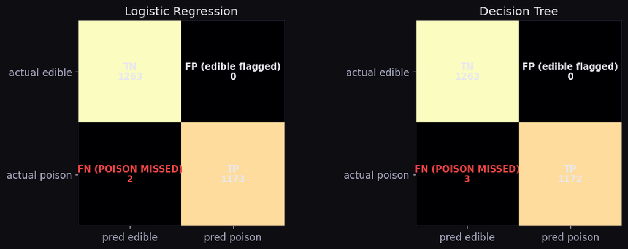

```
Logistic Regression let 2 poisonous mushrooms through as edible.
```

```python
def plot_cm(cm, title, ax):
    tn,fp,fn,tp = cm
    M = np.array([[tn,fp],[fn,tp]])
    ax.imshow(M, cmap='magma')
    labels=[['TN','FP (edible flagged)'],['FN (POISON MISSED)','TP']]
    for i in range(2):
        for j in range(2):
            c = RED if (i==1 and j==0 and M[i,j]>0) else '#e8e8ef'
            ax.text(j,i,f'{labels[i][j]}\n{M[i,j]}',ha='center',va='center',color=c,fontsize=10,fontweight='bold')
    ax.set_xticks([0,1]); ax.set_xticklabels(['pred edible','pred poison'])
    ax.set_yticks([0,1]); ax.set_yticklabels(['actual edible','actual poison'])
    ax.set_title(title)

fig, axes = plt.subplots(1,2, figsize=(11,4))
plot_cm(lr_cm,'Logistic Regression', axes[0])
plot_cm(tr_cm,'Decision Tree', axes[1])
plt.tight_layout(); plt.show()
print(f'Logistic Regression let {lr_cm[2]} poisonous mushrooms through as edible.')
```

## 7. ROC, AUC, and tuning the threshold to be safe

The ROC curve and its area (AUC) confirm the models rank poison above edible almost perfectly. But the default 0.50 cutoff is a business decision, not a law of nature. Since a missed poison is the error that matters, the threshold can be lowered so the model errs toward caution: flag anything with even a modest probability of being poisonous.

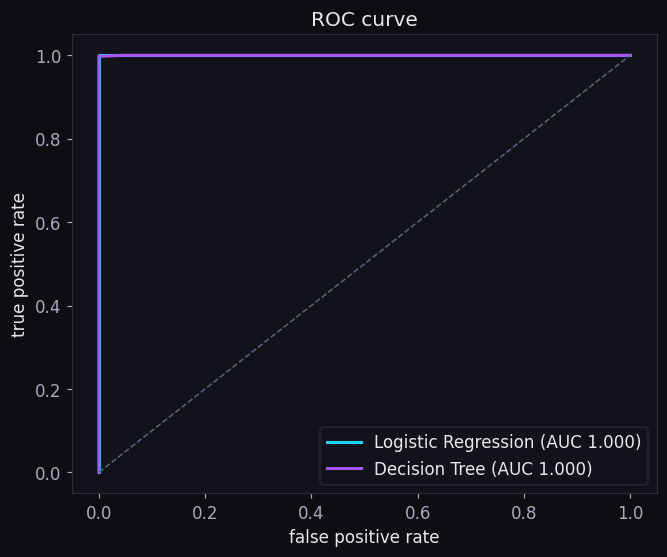

```
Lowering the cutoff to 0.387 catches every poisonous mushroom (0 false negatives) with precision 1.000.
```

```python
fig, ax = plt.subplots(figsize=(6.2,5.2))
for proba,name,col in [(lr_p,'Logistic Regression',CY),(tr_p,'Decision Tree',PU)]:
    fpr,tpr,_ = roc_curve(yte,proba)
    ax.plot(fpr,tpr,color=col,lw=2,label=f'{name} (AUC {roc_auc_score(yte,proba):.3f})')
ax.plot([0,1],[0,1],'--',color='#5a6480',lw=1)
ax.set_xlabel('false positive rate'); ax.set_ylabel('true positive rate')
ax.set_title('ROC curve'); ax.legend(facecolor='#12121a',edgecolor='#2a2a3a',labelcolor='#e8e8ef')
plt.tight_layout(); plt.show()

# lowest threshold with zero missed poison
for thr in np.linspace(0.5,0.001,500):
    tn,fp,fn,tp = confusion_matrix(yte,(lr_p>=thr).astype(int)).ravel()
    if fn==0:
        print(f'Lowering the cutoff to {thr:.3f} catches every poisonous mushroom '
              f'(0 false negatives) with precision {tp/(tp+fp):.3f}.')
        break
```

## 8. What the model learned

Feature importance from the tree confirms the intuition from the exploration step: **odor dominates**, with a supporting cast of spore print color, stalk traits, and ring type. The tree's top rules read almost like a foraging heuristic.

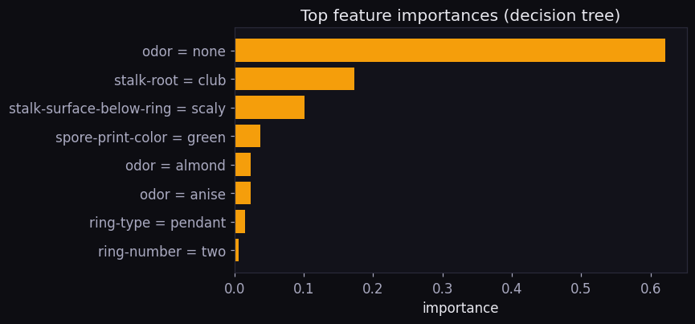

```
First rules of the tree:
|--- odor=n <= 0.50
|   |--- stalk-root=c <= 0.50
|   |   |--- stalk-surface-below-ring=y <= 0.50
|   |   |   |--- odor=a <= 0.50
|   |   |   |   |--- odor=l <= 0.50
|   |   |   |   |   |--- class: 1
|   |   |   |   |--- odor=l >  0.50
|   |   |   |   |   |--- class: 0
|   |   |   |--- odor=a >  0.50
|   |   |   |   |--- class: 0
|   |   |--- stalk-surface-below-ring=y >  0.50
|   |   |   |--- class: 0
|   |--- stalk-root=c >  0.50
|   |   |--- ring-type=p <= 0.50
```

```python
imp = sorted(zip(X.columns, tree.feature_importances_), key=lambda t:-t[1])
top = [(f"{c.split('=')[0]} = {human(c.split('=')[0], c.split('=',1)[1])}", round(v,3))
       for c,v in imp[:8] if v>0]
fig, ax = plt.subplots(figsize=(8,3.8))
labs=[t[0] for t in top][::-1]; vals=[t[1] for t in top][::-1]
ax.barh(labs, vals, color=AM); ax.set_title('Top feature importances (decision tree)')
ax.set_xlabel('importance'); plt.tight_layout(); plt.show()

print('First rules of the tree:')
print('\n'.join(export_text(tree, feature_names=list(X.columns)).splitlines()[:14]))
```

## 9. Conclusions and limits

**What holds up.**

- The problem is nearly separable: two well-chosen features (odor, spore print color) already carry most of the signal, and both models exceed 99.8 percent accuracy.
- The important finding is not the accuracy, it is the **shape of the errors**. Every mistake was a missed poison, which is why the confusion matrix, precision, recall, and a tuned threshold matter more than a single accuracy number.
- One-hot encoding plus a shallow, interpretable tree gives a model whose rules a human can read and trust.

**What this is not.**

- This is a clean, curated dataset from a field guide. Real foraging is far messier: lighting, decay, regional variants, and human error all degrade the signal.
- No one should ever eat a wild mushroom based on a model. The value here is the method, not a foraging tool.

**Why it matters.** Fraud detection, disease screening, and safety alerts share this exact shape: rare, high-cost errors where accuracy is a trap and the confusion matrix is the truth. The subject is playful. The reasoning transfers directly.

*Data: UCI Machine Learning Repository (Mushroom). Analysis and visuals by AbleVLabs.*